# Monte Carlo Investigation: The Six-Sided Die Population

Author

Pui Yin Lim

## 1. Population & Theoretical Baseline

- **Population Distribution:** Discrete Uniform Distribution representing a fair six-sided die, generated via `sample(1:6, size, replace = TRUE)`. Possible outcomes are $X \in \{1, 2, 3, 4, 5, 6\}$, each with probability $p = \frac{1}{6}$.
- **Theoretical Mean (**$\mu$): $\mu = \frac{1 + 2 + 3 + 4 + 5 + 6}{6} = 3.5$
- **Theoretical Standard Deviation (**$\sigma$): $\sigma = \sqrt{\frac{(1-3.5)^2 + \dots + (6-3.5)^2}{6}} = \sqrt{\frac{35}{12}} \approx 1.7078$
- **Theoretical Standard Error (**$\text{SE}$): $\frac{\sigma}{\sqrt{n}} = \frac{\sqrt{35/12}}{\sqrt{n}}$

## 2. Expectations Before Simulation

The underlying population is discrete and heavily bounded so rather than continuous, it’s expected that small sample sizes (like $n = 2$ or $n = 5$) will produce visibly jagged sampling distributions due to the limited combinations possible. However, since the variance is finite ($\sigma^2 \approx 2.9167$), the CLT fully applies so the distribution is expected to progressively smooth out into a bell shape as $n$ increases.

## 3. Simulation Setup & Execution

Simulating $B = 10,000$ Monte Carlo repetitions across sample sizes $n \in \{2, 5, 15, 30\}$ to observe how a discrete distribution converges to normality.

```r
library(tidyverse)
library(knitr)

theo_sigma <- sqrt(35 / 12)

# Create a data frame for the explanation table
die_explanation_table <- tibble(
  Sample_Size = c("n = 2", "n = 5", "n = 15", "n = 30"),
  Theoretical_SE = c("≈ 1.2076", "≈ 0.7638", "≈ 0.4409", "≈ 0.3117"),
  Interpretation = c(
    "The minimum sample size showing strong discreteness. The sampling distribution exhibits multi-modal stepped patterns due to limited combinations, with the highest standard error.",
    "A small sample size where discrete gaps are still visible, though intermediate fractional means begin to fill in, reducing the standard error.",
    "An intermediate sample size approaching the CLT threshold. The stepped multi-modal shape largely dissolves into a symmetric bell curve.",
    "The classical CLT threshold where the distribution achieves approximate normality. Discreteness is virtually gone, replaced by a smooth normal curve and low standard error."
  )
)

kable(
  die_explanation_table,
  col.names = c("Sample Size", "Theoretical SE", "Description & Interpretation"),
  align = c("c", "c", "l")
)
```

Table 1: Rationale for Sample Size Selection (Six-Sided Die Population)

| Sample Size | Theoretical SE | Description & Interpretation |
| --- | --- | --- |
| n = 2 | ≈ 1.2076 | The minimum sample size showing strong discreteness. The sampling distribution exhibits multi-modal stepped patterns due to limited combinations, with the highest standard error. |
| n = 5 | ≈ 0.7638 | A small sample size where discrete gaps are still visible, though intermediate fractional means begin to fill in, reducing the standard error. |
| n = 15 | ≈ 0.4409 | An intermediate sample size approaching the CLT threshold. The stepped multi-modal shape largely dissolves into a symmetric bell curve. |
| n = 30 | ≈ 0.3117 | The classical CLT threshold where the distribution achieves approximate normality. Discreteness is virtually gone, replaced by a smooth normal curve and low standard error. |

```r
library(tidyverse)
library(moments)

# Reproducible seed using last 4 digits of student ID
student_id <- 5678
set.seed(student_id)

B <- 10000                  # Number of Monte Carlo simulations
sample_sizes <- c(2, 5, 15, 30) # Sample sizes to investigate

# Run simulation dynamically for all sample sizes using map_dfr
sim_data <- map_dfr(sample_sizes, function(n_val) {
  sample_means <- replicate(B, mean(sample(1:6, size = n_val, replace = TRUE)))
  tibble(
    n = factor(n_val, levels = sample_sizes),
    sample_mean = sample_means
  )
})
```

## 4. Visualization

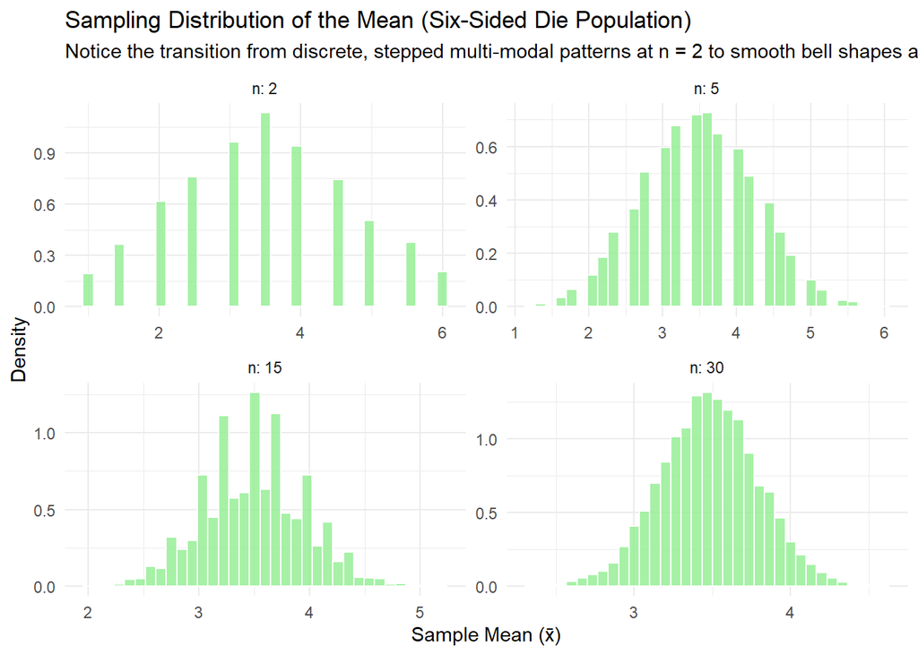

```r
ggplot(sim_data, aes(x = sample_mean)) +
  geom_histogram(aes(y = after_stat(density)), bins = 35, fill = "lightgreen", color = "white", alpha = 0.8) +
  facet_wrap(~n, scales = "free", labeller = label_both) +
  theme_minimal() +
  labs(
    title = "Sampling Distribution of the Mean (Six-Sided Die Population)",
    subtitle = "Notice the transition from discrete, stepped multi-modal patterns at n = 2 to smooth bell shapes at n = 30",
    x = "Sample Mean (x̄)",
    y = "Density"
  )
```

As $n$ grows, the discrete gaps between possible sample means fill in, and the distribution transitions from a seperated and gapped multi-peaked shape into a smooth bell curve, illustrating the Central Limit Theorem as variance contracts via $\text{SE} = \frac{\sigma}{\sqrt{n}}$.

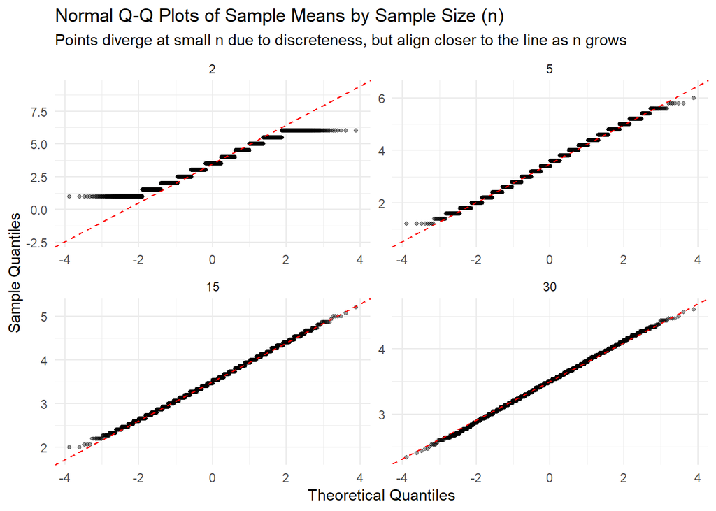

```r
library(ggplot2)

ggplot(sim_data, aes(sample = sample_mean)) +
  geom_qq(alpha = 0.4, size = 1) +
  geom_qq_line(color = "red", linetype = "dashed") +
  facet_wrap(~ n, scales = "free") +
  labs(
    title = "Normal Q-Q Plots of Sample Means by Sample Size (n)",
    subtitle = "Points diverge at small n due to discreteness, but align closer to the line as n grows",
    x = "Theoretical Quantiles",
    y = "Sample Quantiles"
  ) +
  theme_minimal()
```

At small sample sizes ($n = 2$), the Q-Q plot points show stair-step departures from the theoretical normal line due to the discrete nature of the die rolls. As $n$ increases toward $30$, the points hug the reference line much more closely, confirming convergence to normality.

## 5. Numerical Output

```r
summary_table <- sim_data %>%
  group_by(n) %>%
  summarise(
    Simulated_Mean = mean(sample_mean),
    Simulated_SD = sd(sample_mean),
    "Theoretical SE (σ/√n)" = theo_sigma / sqrt(as.numeric(as.character(first(n)))),
    Skewness = moments::skewness(sample_mean),
    Kurtosis = moments::kurtosis(sample_mean)
  )

knitr::kable(
  summary_table,
  caption = "Comparison of Simulated vs. Theoretical Metrics for Six-Sided Die Population",
  digits = 4,
  align = c("c", "c", "c", "c", "c")
)
```

Comparison of Simulated vs. Theoretical Metrics for Six-Sided Die Population

| n | Simulated_Mean | Simulated_SD | Theoretical SE (σ/√n) | Skewness | Kurtosis |
| --- | --- | --- | --- | --- | --- |
| 2 | 3.4806 | 1.2095 | 1.2076 | 0.0430 | 2.3845 |
| 5 | 3.4955 | 0.7599 | 0.7638 | -0.0020 | 2.7501 |
| 15 | 3.5031 | 0.4463 | 0.4410 | 0.0574 | 2.9196 |
| 30 | 3.4974 | 0.3095 | 0.3118 | -0.0236 | 2.9789 |

**Simulated Mean:** Stays consistently centered around $\mu = 3.5$ across all sample sizes, confirming that the sample mean remains an unbiased estimator regardless of the discrete parent population.

**Skewness:** Stays very close to $0$ across all sample sizes because the discrete uniform distribution of a fair die is perfectly symmetric from the start.

**Kurtosis:** Converges toward $3$ as $n$ increases and the distribution transitions from discrete steps into a standard bell-shaped normal curve.

## 6. In Summary

**1. What does the original population distribution look like?**

The parent population is a Discrete Uniform Distribution ($X \in \{1, 2, 3, 4, 5, 6\}$), which is symmetric, bounded, discrete, and flat (each outcome has a probability of $\frac{1}{6}$).

**2. How quickly does the sampling distribution become approximately normal?**

It becomes normal gradually, due to the discrete nature of the die, small sample sizes ($n = 2, 5$) exhibit noticeable stepped or jagged multi-modal patterns that the Central Limit Theorem smooths out into an approximate normal distribution by $n = 15$ to $n = 30$.

**4. How does the simulated standard error compare with** $\text{SE}(\bar{x}) = \frac{\sigma}{\sqrt{n}}$?

The simulated standard deviations track the theoretical standard error formula ($\text{SE} = \frac{\sqrt{35/12}}{\sqrt{n}}$) with high precision across all tested sample sizes.

**5. What evidence supports your conclusion that the distribution is approximately normal?**

Histograms transition from discrete bar groupings into smooth bell curves, Q-Q plot points increasingly hug the red diagonal line, skewness remains near $0$, and kurtosis converges toward $3$.

**6. What limitations or surprises did you observe?**

The primary observation is the visual “discreteness penalty” at low sample sizes ($n = 2$) where only specific fractional means are mathematically possible. As $n$ increases, the combination of outcomes created a near-continuous distribution densely populating the intermediate values, turning a discrete set of steps into a continuous, smooth bell-shaped normal curve.